# OneWay (Between-Subjects) Tutorial with Data

Craig A. Wendorf

2020-02-25

### Enter Data

This code inputs the variable names and creates a viewable data frame.

```r
Factor <- c(rep(1,4),rep(2,4),rep(3,4))
Outcome <- c(0,0,3,5,4,7,4,9,9,6,4,9)
Factor <- factor(Factor,levels=c(1,2,3),labels=c("Level1","Level2","Level3"))
OneWayData <- data.frame(Factor,Outcome)
```

### Analyses of Multiple Groups

This section produces analyses that are equivalent to one-sample analyses separately for each level of a factor.

#### Confidence Intervals for the Means

This code will provide a table of descriptive statistics and confidence intervals for each level of the factor.

```r
estimateMeans(Outcome~Factor)
```

```
## Confidence Intervals for the Means
##
##              N       M      SD      SE      LL      UL
## Level1   4.000   2.000   2.449   1.225  -1.898   5.898
## Level2   4.000   6.000   2.449   1.225   2.102   9.898
## Level3   4.000   7.000   2.449   1.225   3.102  10.898
```

The code defaults to 95% confidence intervals. This can be changed if desired.

```r
estimateMeans(Outcome~Factor,conf.level=.99)
```

```
## Confidence Intervals for the Means
##
##              N       M      SD      SE      LL      UL
## Level1   4.000   2.000   2.449   1.225  -5.154   9.154
## Level2   4.000   6.000   2.449   1.225  -1.154  13.154
## Level3   4.000   7.000   2.449   1.225  -0.154  14.154
```

#### Plots of the Confidence Intervals for the Means

This code will produce a graph of the confidence intervals for each level of the factor.

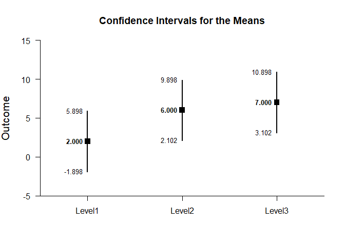

```r
plotMeans(Outcome~Factor)
```

Of course, it is possible to change from the default confidence level. Additionally, it is possible to add a comparison line to represent a population (or test) value and a region of practical equivalence.

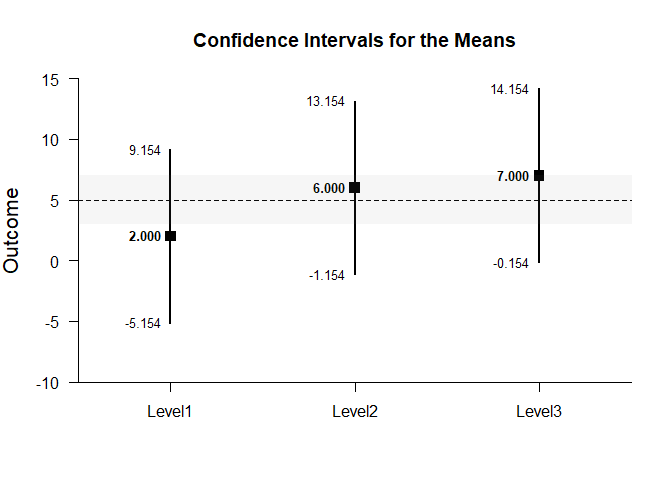

```r
plotMeans(Outcome~Factor,conf.level=.99,mu=5,rope=c(3,7))
```

#### Significance Tests for the Means

This code will produce a table of NHST separately for each level of the factor. In this case, all the means are tested against a value of zero.

```r
testMeans(Outcome~Factor)
```

```
## Hypothesis Tests for the Means
##
##           Diff      SE       t      df       p
## Level1   2.000   1.225   1.633   3.000   0.201
## Level2   6.000   1.225   4.899   3.000   0.016
## Level3   7.000   1.225   5.715   3.000   0.011
```

Often, the default test value of zero is not meaningful or plausible. This too can be altered (often in conjunction with what is presented in the plot).

```r
testMeans(Outcome~Factor,mu=5)
```

```
## Hypothesis Tests for the Means
##
##           Diff      SE       t      df       p
## Level1  -3.000   1.225  -2.449   3.000   0.092
## Level2   1.000   1.225   0.816   3.000   0.474
## Level3   2.000   1.225   1.633   3.000   0.201
```

#### Effect Sizes for the Means

This code will produce a table of standardized mean differences separately for each level of the factor. In this case, the mean is compared to zero to form the effect size.

```r
standardizeMeans(Outcome~Factor)
```

```
## Confidence Intervals for the Standardized Means
##
##              d  d.unb.      SE      LL      UL
## Level1   0.816   0.594   0.616  -0.387   1.934
## Level2   2.449   1.781   0.955   0.325   4.531
## Level3   2.858   2.078   1.063   0.464   5.226
```

Here too it is possible to alter the width of the confidence intervals and to establish a more plausible comparison value for the effect size.

```r
standardizeMeans(Outcome~Factor,mu=5,conf.level=.99)
```

```
## Confidence Intervals for the Standardized Means
##
##              d  d.unb.      SE      LL      UL
## Level1  -1.225  -0.891   0.680  -3.010   0.547
## Level2   0.408   0.297   0.574  -0.969   1.734
## Level3   0.816   0.594   0.616  -0.732   2.319
```

### Analyses of a Group Comparison

This section produces analyses that are equivalent to comparisons of two levels of a factor.

This code creates a new factor that identifies the two levels for comparison.

```r
Comparison=factor(Factor,c("Level1","Level2"))
```

#### Confidence Interval for a Mean Difference

This code estimates the confidence interval of the difference.

```r
estimateDifference(Outcome~Comparison)
```

```
## Confidence Interval for the Comparison
##
##               Diff      SE      df      LL      UL
## Comparison   4.000   1.732   6.000  -0.238   8.238
```

Of course, you can change the confidence level from the default 95% if desired.

```r
estimateDifference(Outcome~Comparison,conf.level=.99)
```

```
## Confidence Interval for the Comparison
##
##               Diff      SE      df      LL      UL
## Comparison   4.000   1.732   6.000  -2.421  10.421
```

#### Plot of the Confidence Interval for a Mean Difference

This code obtains and plots the confidence intervals for the groups and the mean difference in the identified comparison.

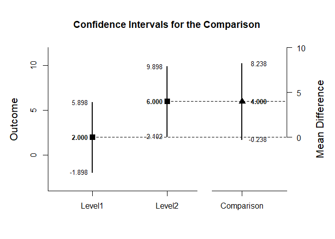

```r
plotDifference(Outcome~Comparison)
```

Once again, the confidence levels can be changed away from the default and a region of practical equivalence can be added.

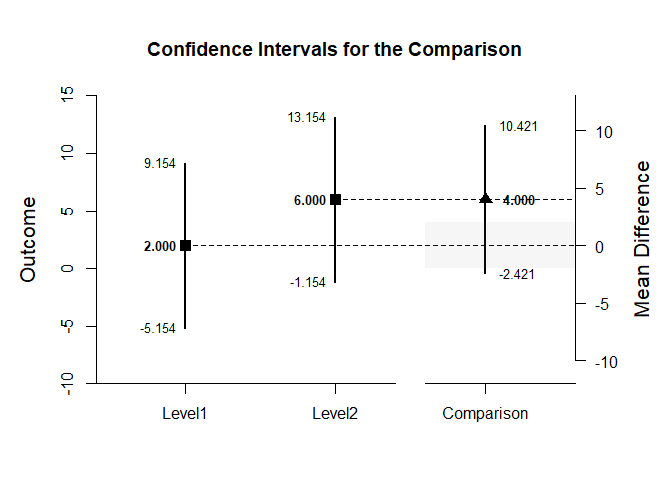

```r
plotDifference(Outcome~Comparison,conf.level=.99,rope=c(-2,2))
```

#### Significance Test for a Mean Difference

This code produces NHST for the identified comparison (using a default test value of zero).

```r
testDifference(Outcome~Comparison)
```

```
## Hypothesis Test for the Comparison
##
##               Diff      SE       t      df       p
## Comparison   4.000   1.732   2.309   6.000   0.060
```

If the default value of zero is not plausible, it too can be changed.

```r
testDifference(Outcome~Comparison,mu=-2)
```

```
## Hypothesis Test for the Comparison
##
##               Diff      SE       t      df       p
## Comparison   6.000   1.732   3.464   6.000   0.013
```

#### Effect Size for the Mean Difference

This code calculates a standardized mean difference for the comparison and its confidence interval.

```r
standardizeDifference(Outcome~Comparison)
```

```
## Confidence Interval for the Standardized Comparison
##
##                Est      SE      LL      UL
## Comparison   1.633   0.943  -0.215   3.481
```

The width of the confidence interval for the effect size can be altered if desired.

```r
standardizeDifference(Outcome~Comparison,conf.level=.99)
```

```
## Confidence Interval for the Standardized Comparison
##
##                Est      SE      LL      UL
## Comparison   1.633   0.943  -0.796   4.062
```

### Analyses of a Group Contrast

This section produces analyses that are equivalent to analyses involving multiple levels of a factor.

This code identifies a contrast among the groups.

```r
L1vsOthers <- c(-1,.5,.5)
```

#### Confidence Interval for a Contrast

This code produces a confidence interval for that contrast.

```r
estimateContrast(Outcome~Factor,contrast=L1vsOthers)
```

```
## Confidence Interval for the Contrast
##
##              Est      SE      df      LL      UL
## Contrast   4.500   1.500   6.000   0.830   8.170
```

As in all other cases, the default value of the confidence interval can be changed.

```r
estimateContrast(Outcome~Factor,contrast=L1vsOthers,conf.level=.99)
```

[output not shown]

#### Plots of Confidence Intervals for a Contrast

This code obtains and plots the confidence intervals for the groups and the mean difference in the identified contrast.

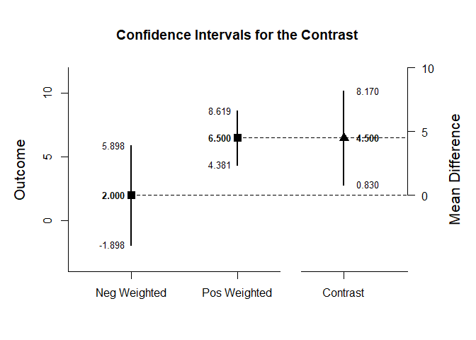

```r
plotContrast(Outcome~Factor,contrast=L1vsOthers)
```

The width of the confidence interval for the contrast can be altered and a region of practical equivalence can be added.

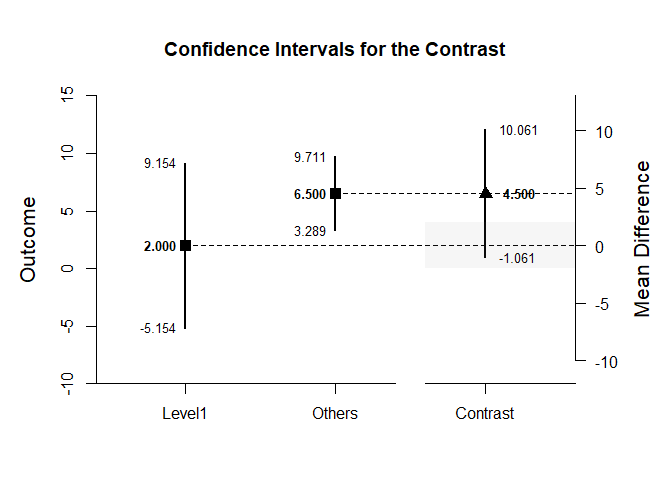

```r
plotContrast(Outcome~Factor,contrast=L1vsOthers,labels=c("Level1","Others"),conf.level=.99,rope=c(-2,2))
```

#### Significance Test for a Contrast

This code produces a NHST for the identified contrast. It tests the contrast against a value of zero by default.

```r
testContrast(Outcome~Factor,contrast=L1vsOthers)
```

```
## Hypothesis Test for the Contrast
##
##              Est      SE       t      df       p
## Contrast   4.500   1.500   3.000   6.000   0.024
```

If desired, the contrast can be tested against other values.

```r
testContrast(Outcome~Factor,contrast=L1vsOthers,mu=4)
```

```
## Hypothesis Test for the Contrast
##
##              Est      SE       t      df       p
## Contrast   0.500   1.500   0.333   6.000   0.750
```

#### Effect Size for a Contrast

This code calculates a standardized contrast and its confidence interval.

```r
standardizeContrast(Outcome~Factor,contrast=L1vsOthers)
```

```
## Confidence Interval for the Standardized Contrast
##
##              Est      SE      LL      UL
## Contrast   1.837   0.829   0.212   3.462
```

The width of the confidence interval for the effect size can be altered if desired.

```r
standardizeContrast(Outcome~Factor,contrast=L1vsOthers,conf.level=.99)
```

```
## Confidence Interval for the Standardized Contrast
##
##              Est      SE      LL      UL
## Contrast   1.837   0.829  -0.299   3.973
```